# Douma and Shipley Multigroup analysis

Bart DiFiore

2024-06-06

The goal of this analysis is to determine if the correlations between different trophic guilds differ between protected and protected sites. Specifically, we are modeling the observational data 5-years post MPA implementation.

Traditional SEM allow for categorical*continuous interactions. However, piecewise SEM’s cannot yet accomodate a global interaction (e.g. MPA_status x everything else). Therefore, I am following Douma and Shipley (2021, Ecosphere). They present a reproducible procedure through which to test for global interactions by imposing sequential contrains on a system of linear regressions.

Specifically, we are interested in understanding not simply if (for example) purple urchin abundance is lower in MPAs, but if the relationship of purple urchins on kelp differs with MPA status.

It is important to note, that for the SEM’s we need each individual linear model to be modeling the same subset of the data. Therefore, we have to **a priori** limit the data set to only observations that are present across all predictors, responses, and grouping variables. In other words, I had to drop all rows in the data set with NA. This caused certain survey’s to be entirely excluded, like the LTER lobster surveys as those surveys do not also include data on purple urchin, sheephead, etc.

The key aspect of this analysis is that we are testing **specific** DAGs that represent hypothesized causal topologies. And we can only test the hypothesized causal topologies against a more-saturated model. In other words the hypothesized model must be nested within a more saturated model. Shipley and Douma ([2020](https://esajournals.onlinelibrary.wiley.com/action/downloadSupplement?doi=10.1002%2Fecy.2960&file=ecy2960-sup-0001-AppendixS1.pdf)) provide an excellent overview for how to develop saturated models with free parameters against which to test hypothesized DAGs.

Here I will start by writing out the fixed effects model structures for our hypothesized DAGs:

DAG 1: This hypothesized causal topology predicts that all endogenous variables can express a different intercept based on MPA status. It also predicts that there will be differences in the path coefficients based on status for all higher trophic levels on kelp, and lobster / sheephead impacts on urchin.

$$
$$\begin{align}
kelp &\sim \beta_0 + \beta_1Status + \beta_2Purple +
\beta_3PurpleStatus + \beta_4Red +
\beta_5RedStatus+\beta_6Lob+\beta_7LobStatus +
\beta_8Sheep+\beta_9SheepStatus \\
purple &\sim \beta_0 + \beta_1Status + \beta_6Lob+\beta_7LobStatus +
\beta_8Sheep+\beta_9SheepStatus \\
red &\sim \beta_0 + \beta_1Status + \beta_6Lob+\beta_7LobStatus +
\beta_8Sheep+\beta_9SheepStatus \\
lob &\sim \beta_0 + \beta_1Status\\
sheep &\sim \beta_0 + \beta_1Status\\
\end{align}$$
$$

DAG 2: An alternative hypothesis could be that only the intercepts vary by status and the coefficients for differences in path coefficients are fixed (at zero). However in this DAG we still assume the same directed paths between endogenous variables.

$$
$$\begin{align}
kelp &\sim \beta_0 + \beta_1Status + \beta_2Purple + 0PurpleStatus +
\beta_4Red + 0RedStatus+\beta_6Lob+0LobStatus +
\beta_8Sheep+0SheepStatus \\
purple &\sim \beta_0 + \beta_1Status + \beta_6Lob+0LobStatus +
\beta_8Sheep+0SheepStatus \\
red &\sim \beta_0 + \beta_1Status + \beta_6Lob+0LobStatus +
\beta_8Sheep+0SheepStatus \\
lob &\sim \beta_0 + \beta_1Status\\
sheep &\sim \beta_0 + \beta_1Status\\
\end{align}$$
$$ In this sense it’s easy to see that DAG 2 is nested withing DAG 1. Thus we can use the Shipley and Douma chi-square test to evaluate model fit.

DAG 3: We might also believe that there is not direct effect of predators on kelp. Rather the effects of predators are conditional on kelp via their effects on urchins. Here we can change the DAG to reflect that hypothesis.

$$
$$\begin{align}
kelp &\sim \beta_0 + \beta_1Status + \beta_2Purple +
\beta_3PurpleStatus + \beta_4Red + \beta_5RedStatus+0Lob+0LobStatus +
0Sheep+0SheepStatus \\
purple &\sim \beta_0 + \beta_1Status + \beta_6Lob+\beta_7LobStatus +
\beta_8Sheep+\beta_9SheepStatus \\
red &\sim \beta_0 + \beta_1Status + \beta_6Lob+\beta_7LobStatus +
\beta_8Sheep+\beta_9SheepStatus \\
lob &\sim \beta_0 + \beta_1Status\\
sheep &\sim \beta_0 + \beta_1Status\\
\end{align}$$
$$

Again, here I’ve used zeros to FIX the parameters so that we can see that this DAG is nested within DAG 1.

You could imagine that there are many different causal topologies that we could test that are nested within DAG 1. We can and should explore more of these causal hypothesis. However, for times sake I’ll only test a few that I think are most relevant.

DAG 4: We could also create simplier DAG’s where the effects of predators/consumers are more specific. For instance, here we assume that the effect of purple urchins on kelp differs by status. And that that effect is due to differences in lobster impacts on purple urchins by status.

$$
$$\begin{align}
kelp &\sim \beta_0 + \beta_1Status + \beta_2Purple +
\beta_3PurpleStatus + \beta_4Red + 0RedStatus+0Lob+0LobStatus +
0Sheep+0SheepStatus \\
purple &\sim \beta_0 + \beta_1Status + \beta_6Lob+\beta_7LobStatus +
\beta_8Sheep+0SheepStatus \\
red &\sim \beta_0 + \beta_1Status + \beta_6Lob+0LobStatus +
\beta_8Sheep+0SheepStatus \\
lob &\sim \beta_0 + \beta_1Status\\
sheep &\sim \beta_0 + \beta_1Status\\
\end{align}$$
$$

Dag 5: Another potentially interesting DAG is depicted below

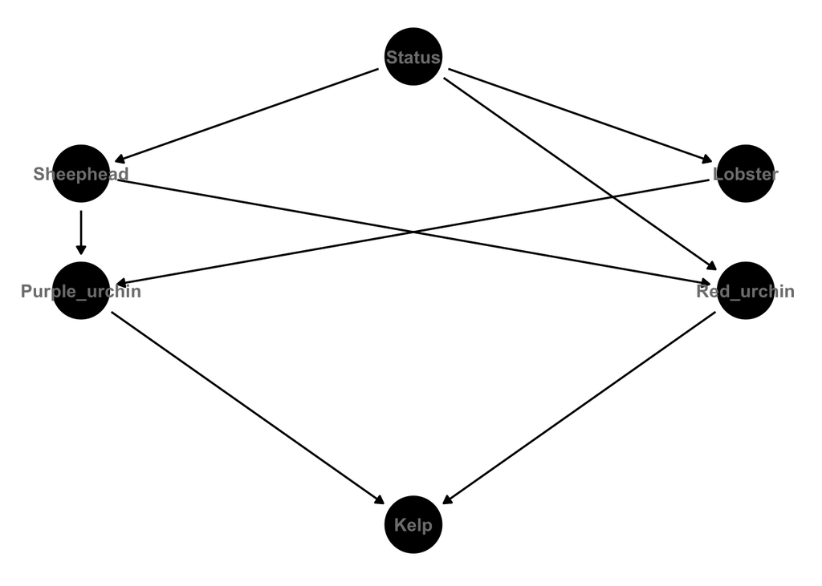

You can see in this DAG that protection status only has direct causal links with sheephead, lobster, and red urchin. Each of these species is commercially and recreationally harvested. Thus, we would predict that MPAs would increase the abundance (e.g. the intercept) of each of these guilds. Increases in the abundance (intercept) of predators could result in changes in the relationship between the predators and the urchin guilds. Thus I this DAG should also allow for differences in the path coefficients by MPA status between predators and prey.

DAG 6: Finally, as somewhat of a “null” model, we can test the hypothesis that all trophic levels are cuasally unrelated. And the only driver is MPA status.

$$
$$\begin{align}
kelp &\sim \beta_0 + \beta_1Status + 0Purple + 0PurpleStatus + 0Red
+ 0RedStatus+0Lob+0LobStatus + 0Sheep+0SheepStatus \\
purple &\sim \beta_0 + \beta_1Status + 0Lob+0LobStatus +
0Sheep+0SheepStatus \\
red &\sim \beta_0 + \beta_1Status + 0Lob+0LobStatus +
0Sheep+0SheepStatus \\
lob &\sim \beta_0 + \beta_1Status\\
sheep &\sim \beta_0 + \beta_1Status\\
\end{align}$$
$$

We should note that each model is nested within DAG 1. Subsequent models *are NOT* (I don’t think???) however necessarily nested within the previous model. For instance, DAG 3 is not nested within DAG 2 *BUT* DAG 5 is nested within DAG 3.

| Model | Model description | Chi-square value | p-value | AIC |
| --- | --- | --- | --- | --- |
| 1 | Path coefficients vary | NA | NA | -387.28 |
| 2 | Path coefficients are fixed | 22.76 | 0.00 | -380.53 |
| 3 | Modification 3 | 12.78 | 0.01 | -382.51 |
| 4 | Modification 4 | 18.59 | 0.00 | -378.70 |
| 5 | Modification 5 | 37.81 | 0.00 | -363.48 |
| 6 | Only status has causal impact | 128.60 | 0.00 | -290.68 |